# ShopifyDS

```python
import seaborn as sns
import matplotlib.pyplot as plt
from collections import Counter
import pandas as pd
import numpy as np
```

```python
df = pd.read_csv("data.csv")

df.describe()
```

|  | order_id | shop_id | user_id | order_amount | total_items |
| --- | --- | --- | --- | --- | --- |
| count | 5000.000000 | 5000.000000 | 5000.000000 | 5000.000000 | 5000.00000 |
| mean | 2500.500000 | 50.078800 | 849.092400 | 3145.128000 | 8.78720 |
| std | 1443.520003 | 29.006118 | 87.798982 | 41282.539349 | 116.32032 |
| min | 1.000000 | 1.000000 | 607.000000 | 90.000000 | 1.00000 |
| 25% | 1250.750000 | 24.000000 | 775.000000 | 163.000000 | 1.00000 |
| 50% | 2500.500000 | 50.000000 | 849.000000 | 284.000000 | 2.00000 |
| 75% | 3750.250000 | 75.000000 | 925.000000 | 390.000000 | 3.00000 |
| max | 5000.000000 | 100.000000 | 999.000000 | 704000.000000 | 2000.00000 |

```python
df.info()
```

```
<class 'pandas.core.frame.DataFrame'>
RangeIndex: 5000 entries, 0 to 4999
Data columns (total 7 columns):
 #   Column          Non-Null Count  Dtype
---  ------          --------------  -----
 0   order_id        5000 non-null   int64
 1   shop_id         5000 non-null   int64
 2   user_id         5000 non-null   int64
 3   order_amount    5000 non-null   int64
 4   total_items     5000 non-null   int64
 5   payment_method  5000 non-null   object
 6   created_at      5000 non-null   object
dtypes: int64(5), object(2)
memory usage: 273.6+ KB
```

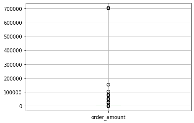

```python
#boxplot
df.boxplot(column='order_amount')
```

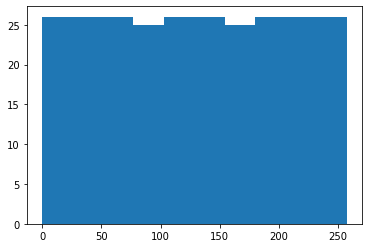

```python
# using a counter to observe the distribution and propotions of number of orders
counter_obj = Counter(df.order_amount)

counter_obj.most_common()

w= [x for x , y in enumerate(counter_obj)]

plt.hist(w)
```

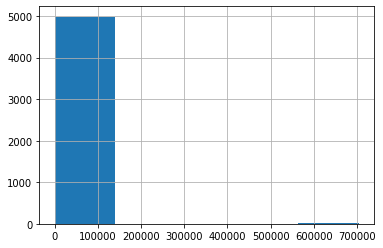

```python
# distribution
df['order_amount'].hist(bins=5)
```

## given the baove distribution an outlier is evident and we have the distribution Skewed to the lower end values

```python
# Z score
df['col_zscore'] = (df['order_amount'] - df['order_amount'].mean())/df['order_amount'].std(ddof=0)
```

```python
z_scores = np.abs(df['col_zscore'])
filtered_data = (z_scores < 3)
df_filtered = df[filtered_data]
```

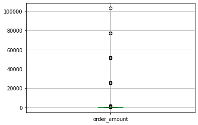

```python
# created a new box plot for the new dataframe
df_filtered.boxplot(column='order_amount')
```

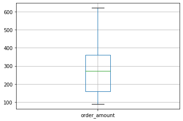

```python
# As the outliers have been removed using  the z score filter , we can be comfortable with increasing out interquartile range betweenn 15th and 85th percentile
IQR = df.order_amount.quantile(q=0.85) - df.order_amount.quantile(q=0.15)
no_outliers = df_filtered[(df_filtered.order_amount <df.order_amount.quantile(q=0.5)  + IQR ) & (df_filtered.order_amount > df_filtered.order_amount.quantile(q=0.5) - IQR )]
no_outliers.boxplot(column='order_amount')
```

## Q1 b) Use the mean of the new data frame as the median and the mean are so close when the outliers were removed form the data frame so using the mean of the new data will get a more precise answer

```python
df_no_outliers['order_amount'].median()
```

```
272.0
```

```python
no_outliers.describe()
```

|  | order_id | shop_id | user_id | order_amount | total_items | col_zscore |
| --- | --- | --- | --- | --- | --- | --- |
| count | 4729.000000 | 4729.000000 | 4729.000000 | 4729.000000 | 4729.000000 | 4729.000000 |
| mean | 2502.060266 | 49.815183 | 850.391415 | 283.166843 | 1.894481 | -0.069333 |
| std | 1443.847867 | 29.148638 | 86.795655 | 131.350139 | 0.858710 | 0.003182 |
| min | 1.000000 | 1.000000 | 700.000000 | 90.000000 | 1.000000 | -0.074013 |
| 25% | 1249.000000 | 24.000000 | 776.000000 | 161.000000 | 1.000000 | -0.072293 |
| 50% | 2505.000000 | 50.000000 | 851.000000 | 272.000000 | 2.000000 | -0.069604 |
| 75% | 3757.000000 | 74.000000 | 926.000000 | 362.000000 | 2.000000 | -0.067423 |
| max | 5000.000000 | 100.000000 | 999.000000 | 620.000000 | 5.000000 | -0.061173 |

## Q1 C) 283.166843

## Question 2 part a --> 54

SELECT COUNT(*) FROM Orders , Shippers WHERE ShipperName = "Speedy Express" AND Orders.ShipperId = Shippers.ShipperId;

## Question 2 part b -->Peacock with 40 orders

SELECT [Employees].LastName, COUNT(*) AS x FROM [Orders] JOIN [Employees] ON [Orders].EmployeeID = [Employees].EmployeeID GROUP BY [Employees].LastName ORDER BY x DESC LIMIT 1;

## Question 2 part c --> Boston Crab Meat with 160 orders

SELECT ProductName, sum(Quantity) as tot from Products Natural join orders Natural join orderDetails Natural join Customers WHERE Customers.Country = 'Germany' group by ProductName ORDER BY tot DESC LIMIT 1;